# Chapter 2: Review of the Linear Regression Model

### Setup

```r
#setwd("/Users/anjali/Documents/university/Econ_5305/Econ5305/Chapter2")
library(readxl)
rm(list = ls())
data <- read_excel("FRED_series_GDP_SP500_complete.xlsx")
View(data)
```

### Question 2: EDA

Download the U.S. GDP quarterly growth rates and the Standard & Poor’s (SP) 500 quarterly returns. For both series, compute their descriptive statistics and their histograms. Are these two series contemporaneously correlated? Comment on your findings.

```r
summary(data)
```

```
 observation_date                    GDP_PCH          SP500_PCH
 Min.   :2013-07-01 00:00:00.00   Min.   :-8.8276   Min.   :-8.0242
 1st Qu.:2015-10-24 00:00:00.00   1st Qu.: 0.8126   1st Qu.:-0.4496
 Median :2018-02-15 00:00:00.00   Median : 1.2268   Median : 3.3336
 Mean   :2018-02-14 17:41:03.16   Mean   : 1.2109   Mean   : 2.4194
 3rd Qu.:2020-06-08 06:00:00.00   3rd Qu.: 1.6293   3rd Qu.: 5.4920
 Max.   :2022-10-01 00:00:00.00   Max.   : 8.7881   Max.   :13.2397
```

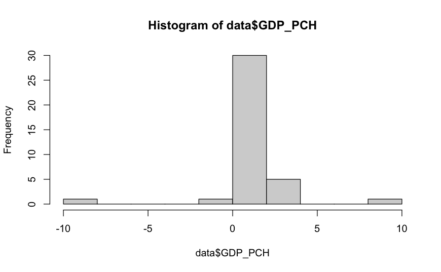

```r
hist(data$GDP_PCH)
```

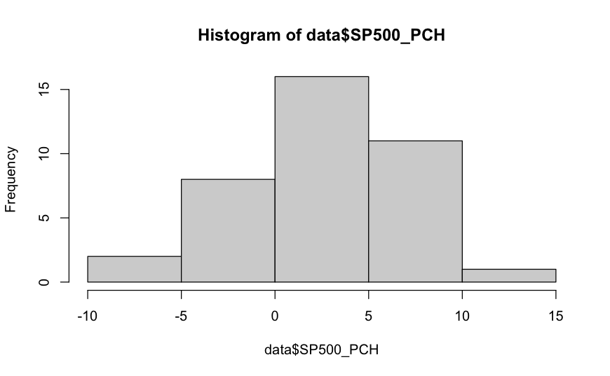

```r
hist(data$SP500_PCH)
```

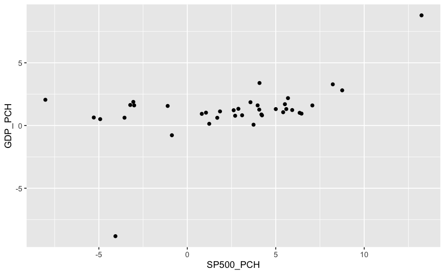

```r
library(ggplot2)
# Scatter plot
ggplot(data,aes(x=SP500_PCH, y=GDP_PCH)) + geom_point()
```

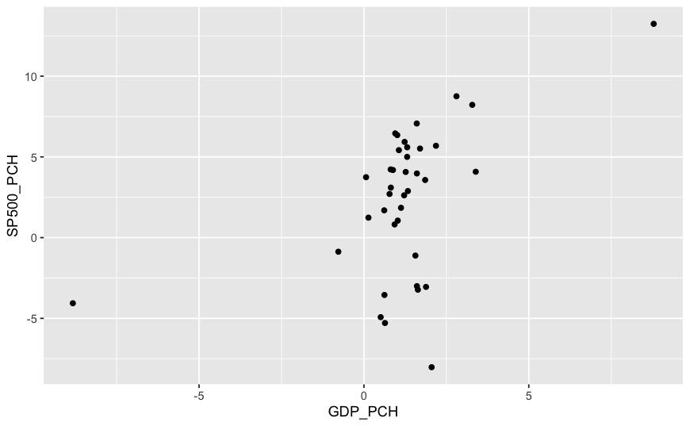

```r
ggplot(data,aes(x=GDP_PCH, y=SP500_PCH)) + geom_point()
```

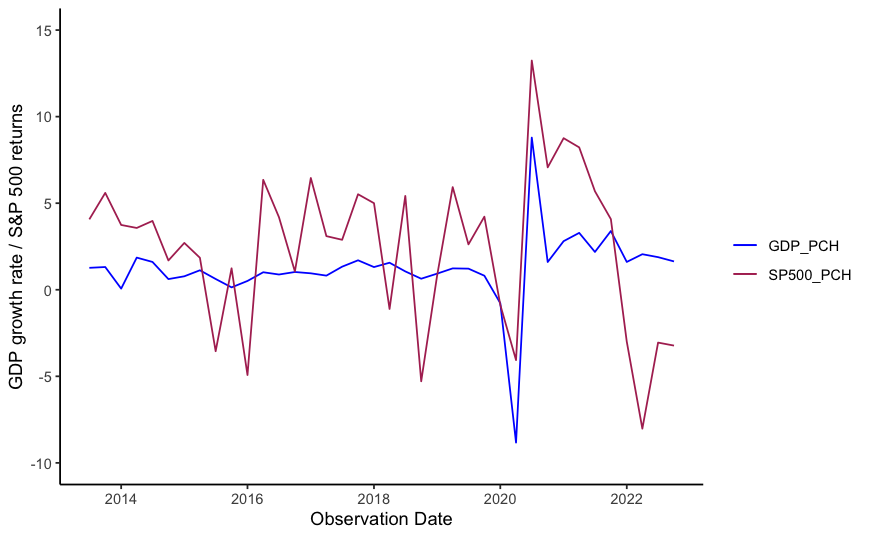

```r
# Line plot
ggplot( data, aes(x = observation_date )) +
  #add one line for Export
  geom_line(aes(y = GDP_PCH , colour = "GDP_PCH") ) +
  # add another line for Import
  geom_line(aes(y = SP500_PCH , colour = "SP500_PCH")) +
  theme_classic() +
  scale_y_continuous(limits = c(-10,15)) +
  scale_color_manual(name = '',
                       breaks = c( "GDP_PCH" , "SP500_PCH" ),
                       values = c( "GDP_PCH" =  'blue' ,
                                   "SP500_PCH" = 'maroon' )
                       ) +
  ylab( "GDP growth rate / S&P 500 returns") +
  xlab("Observation Date")
```

```r
cat ("Linear correlation between the two series: ", cor(data$GDP_PCH,data$SP500_PCH))
```

```
Linear correlation between the two series:  0.4891607
```

```r
cat ("\nPolynomial(2) Correlation between the two series: ", cor(data$GDP_PCH,data$SP500_PCH^2))
```

```
Polynomial(2) Correlation between the two series:  0.5868791
```

```r
cat ("\nPolynomial(3) Correlation between the two series: ", cor(data$GDP_PCH,data$SP500_PCH^3))
```

```
Polynomial(3) Correlation between the two series:  0.6083697
```

```r
cat ("\nPolynomial(4) Correlation between the two series: ", cor(data$GDP_PCH,data$SP500_PCH^4))
```

```
Polynomial(4) Correlation between the two series:  0.613711
```

```r
cat( "Standard deviation for GDP: ", sd(data$GDP_PCH),"\nStandard deviation for SP500:", sd(data$SP500_PCH))
```

```
Standard deviation for GDP:  2.218885
Standard deviation for SP500: 4.478321
```

**Key Findings:**

- Difference in Volatility: GDP and S&P stayed in a similar range, but S&P is more more volatile considering its histogram and the standard deviation which is higher almost double (4.5 vs 2.2) as compared to GDP.GDP and S&P move towards the same direction.
- From scatter plot: GDP and S&P are likely to have a linear relationship based on the scatter plot there is linear correlation of 0.4891. However it is interesting to note that using polynomial degree 2 the correlation is 0.58 and therefore there might be some some non-linear correlation possibilities that could also be explored. This is more open ended and with more data maybe clearer patterns can be seen.
- Line Graphs: They move on par specially on big swings like during the COVID crisis but often have opposite movement in some years like in around 2016.

### Question 3: Run OLS for Following Models

#### Model a: Y(t) = B0 + B1.X(t)

```r
model_a <- lm(data$GDP_PCH ~ data$SP500_PCH)
summary(model_a)
```

```
Call:
lm(formula = data$GDP_PCH ~ data$SP500_PCH)

Residuals:
    Min      1Q  Median      3Q     Max
-8.4673 -0.7535 -0.0154  0.8108  4.9547

Coefficients:
               Estimate Std. Error t value Pr(>|t|)
(Intercept)     0.62453    0.36286   1.721  0.09381 .
data$SP500_PCH  0.24237    0.07202   3.365  0.00183 **
---
Signif. codes:  0 ‘***’ 0.001 ‘**’ 0.01 ‘*’ 0.05 ‘.’ 0.1 ‘ ’ 1

Residual standard error: 1.962 on 36 degrees of freedom
Multiple R-squared:  0.2393,    Adjusted R-squared:  0.2181
F-statistic: 11.32 on 1 and 36 DF,  p-value: 0.00183
```

```r
#plot(model_a)
```

#### Model b: Y(t) = B0 + B1.X(t-1)

```r
library(dynlm)
# The frequency is the number of observations per year.
# Annual    1; Quarterly    4; Monthly  12; Weekly  52
T_GDP<-ts(data$GDP_PCH,frequency=4, start=c(2013,7))
T_SP500<-ts(data$SP500_PCH,frequency=4, start=c(2013,7))

# if they are time series
is.ts(T_GDP)
```

```
[1] TRUE
```

```r
is.ts(T_SP500)
```

```
[1] TRUE
```

```r
model_b<-dynlm(T_GDP ~ stats::lag(T_SP500,-1))
summary(model_b)
```

```
Time series regression with "ts" data:
Start = 2014(4), End = 2023(4)

Call:
dynlm(formula = T_GDP ~ stats::lag(T_SP500, -1))

Residuals:
    Min      1Q  Median      3Q     Max
-9.9863 -0.4189 -0.0395  0.4875  7.6765

Coefficients:
                        Estimate Std. Error t value Pr(>|t|)
(Intercept)              1.17149    0.43479   2.694   0.0108 *
stats::lag(T_SP500, -1)  0.01474    0.08562   0.172   0.8643
---
Signif. codes:  0 ‘***’ 0.001 ‘**’ 0.01 ‘*’ 0.05 ‘.’ 0.1 ‘ ’ 1

Residual standard error: 2.28 on 35 degrees of freedom
Multiple R-squared:  0.0008459, Adjusted R-squared:  -0.0277
F-statistic: 0.02963 on 1 and 35 DF,  p-value: 0.8643
```

```r
#plot(model_b)
```

```r
model_c<-dynlm(T_GDP ~ stats::lag(T_SP500,-1) + stats::lag(T_SP500,-2) + stats::lag(T_SP500,-3) + stats::lag(T_SP500,-4))
summary(model_c)
```

```
Time series regression with "ts" data:
Start = 2015(3), End = 2023(4)

Call:
dynlm(formula = T_GDP ~ stats::lag(T_SP500, -1) + stats::lag(T_SP500,
    -2) + stats::lag(T_SP500, -3) + stats::lag(T_SP500, -4))

Residuals:
    Min      1Q  Median      3Q     Max
-9.8626 -0.5098  0.1858  0.6152  7.4963

Coefficients:
                        Estimate Std. Error t value Pr(>|t|)
(Intercept)              1.10800    0.66377   1.669    0.106
stats::lag(T_SP500, -1)  0.01222    0.09669   0.126    0.900
stats::lag(T_SP500, -2) -0.01019    0.09964  -0.102    0.919
stats::lag(T_SP500, -3)  0.07607    0.10674   0.713    0.482
stats::lag(T_SP500, -4) -0.03688    0.10876  -0.339    0.737

Residual standard error: 2.467 on 29 degrees of freedom
Multiple R-squared:  0.02143,   Adjusted R-squared:  -0.1135
F-statistic: 0.1588 on 4 and 29 DF,  p-value: 0.9574
```

```r
#plot(model_c)
```

```r
model_d<-dynlm(T_GDP ~ stats::lag(T_SP500,-1) + stats::lag(T_SP500,-2) + stats::lag(T_SP500,-3) + stats::lag(T_SP500,-4) + stats::lag(T_GDP,-1))
summary(model_d)
```

```
Time series regression with "ts" data:
Start = 2015(3), End = 2023(4)

Call:
dynlm(formula = T_GDP ~ stats::lag(T_SP500, -1) + stats::lag(T_SP500,
    -2) + stats::lag(T_SP500, -3) + stats::lag(T_SP500, -4) +
    stats::lag(T_GDP, -1))

Residuals:
     Min       1Q   Median       3Q      Max
-10.2774  -0.5465   0.1622   0.9086   4.8087

Coefficients:
                         Estimate Std. Error t value Pr(>|t|)
(Intercept)              1.251820   0.656859   1.906    0.067 .
stats::lag(T_SP500, -1)  0.101750   0.111859   0.910    0.371
stats::lag(T_SP500, -2) -0.024706   0.098023  -0.252    0.803
stats::lag(T_SP500, -3)  0.068475   0.104620   0.655    0.518
stats::lag(T_SP500, -4) -0.006545   0.108378  -0.060    0.952
stats::lag(T_GDP, -1)   -0.322566   0.214747  -1.502    0.144
---
Signif. codes:  0 ‘***’ 0.001 ‘**’ 0.01 ‘*’ 0.05 ‘.’ 0.1 ‘ ’ 1

Residual standard error: 2.416 on 28 degrees of freedom
Multiple R-squared:  0.09441,   Adjusted R-squared:  -0.06731
F-statistic: 0.5838 on 5 and 28 DF,  p-value: 0.7121
```

```r
#plot(model_d)
```

### Question 4: t-ratio tests (a) and (b)

```r
# Helper method for running t-ratio test on any parameter

t_ratio_test.run <-function (m,constant=0,index =1,confidence = 0.05) {
  index <- index + 1
  model_df <- df.residual(m)
  model_summary <- summary(m)
  Beta <- model_summary$coefficients[index,1]
  std_error <- model_summary$coefficients[index,2]

  t_statistic <- (Beta - constant) / std_error

  two_tailed <- qt(p=confidence/2, df= model_df, lower.tail=FALSE)
  right_tailed <- qt(p=confidence, df= model_df, lower.tail=FALSE)
  left_tailed <- qt(p=confidence, df= model_df, lower.tail=TRUE)

  cat(" t-statistic: ",t_statistic,"\n",
      "t-critical two tailed: [", - two_tailed,",", two_tailed,"]\t Reject Hypothesis = ", t_statistic < -two_tailed | t_statistic > two_tailed,"\n",
      "t-critical right tailed: ", right_tailed,"\t Reject Hypothesis = ", t_statistic > right_tailed,"\n",
      "t-critical left tailed: ", left_tailed,"\t Reject Hypothesis = ", t_statistic < left_tailed
      )

}
```

For **model a:** conduct t-ratio test for the following  
1. H0: B1 = 0, H1: b1 != 0  
2. H0: B1 = 0, H1: b1 > 0  
3. H0: B1 = 0, H1: b1 < 0

```r
c <- 0
j <- 1
t_ratio_test.run(model_a,constant = c,index = j,confidence = 0.05)
```

```
 t-statistic:  3.365037
 t-critical two tailed: [ -2.028094 , 2.028094 ]     Reject Hypothesis =  TRUE
 t-critical right tailed:  1.688298      Reject Hypothesis =  TRUE
 t-critical left tailed:  -1.688298      Reject Hypothesis =  FALSE
```

**Key Findings:** The t-statistic is quite large at 3.36. We can reject the null hypothesis in 1. We can similarly reject the null hypothesis in 2 and go with the alternate hypothesis B1 > 0. In 3 however we cannot reject the null hypothesis for the alternate that B1 < 0.

For **model b:** conduct t-ratio test for the following  
1. H0: B1 = 0, H1: b1 != 0  
2. H0: B1 = 0, H1: b1 > 0  
3. H0: B1 = 0, H1: b1 < 0

```r
c <- 0
j <- 1
t_ratio_test.run(model_b,constant = c,index = j,confidence = 0.05)
```

```
 t-statistic:  0.1721381
 t-critical two tailed: [ -2.030108 , 2.030108 ]     Reject Hypothesis =  FALSE
 t-critical right tailed:  1.689572      Reject Hypothesis =  FALSE
 t-critical left tailed:  -1.689572      Reject Hypothesis =  FALSE
```

**Key Findings:** We cannot reject the null hypothesis for 1,2,3. B1 is not statistically significant in the model. This also indicated by the very small t-statistic of 0.1721

```r
# two-tailed version of the function
t_ratio_test_two_tailed.run <-function (m,constant=0,index =1,confidence = 0.05) {
  index <- index + 1
  model_df <- df.residual(m)
  model_summary <- summary(m)
  Beta <- model_summary$coefficients[index,1]
  std_error <- model_summary$coefficients[index,2]

  t_statistic <- (Beta - constant) / std_error

  two_tailed <- qt(p=confidence/2, df= model_df, lower.tail=FALSE)

  cat("\nt-ratio test for Beta =", index - 1, "\nt-statistic: ",t_statistic,
      "\nt-critical two tailed: [", - two_tailed,",", two_tailed,"]\t Reject Hypothesis = ", t_statistic < -two_tailed | t_statistic > two_tailed
      )

}
```

#### Conduct the t-ratio tests for all coefficients

```r
t_ratio_test_two_tailed.run(model_c,constant = 0,index = 1,confidence = 0.05)
```

```
t-ratio test for Beta = 1
t-statistic:  0.1264195
t-critical two tailed: [ -2.04523 , 2.04523 ]    Reject Hypothesis =  FALSE
```

```r
t_ratio_test_two_tailed.run(model_c,constant = 0,index = 2,confidence = 0.05)
```

```
t-ratio test for Beta = 2
t-statistic:  -0.1022796
t-critical two tailed: [ -2.04523 , 2.04523 ]    Reject Hypothesis =  FALSE
```

```r
t_ratio_test_two_tailed.run(model_c,constant = 0,index = 3,confidence = 0.05)
```

```
t-ratio test for Beta = 3
t-statistic:  0.7126616
t-critical two tailed: [ -2.04523 , 2.04523 ]    Reject Hypothesis =  FALSE
```

```r
t_ratio_test_two_tailed.run(model_c,constant = 0,index = 4,confidence = 0.05)
```

```
t-ratio test for Beta = 4
t-statistic:  -0.3390635
t-critical two tailed: [ -2.04523 , 2.04523 ]    Reject Hypothesis =  FALSE
```

#### Conduct the t-ratio tests for all coefficients

```r
t_ratio_test_two_tailed.run(model_d,constant = 0,index = 1,confidence = 0.10)
```

```
t-ratio test for Beta = 1
t-statistic:  0.9096293
t-critical two tailed: [ -1.701131 , 1.701131 ]  Reject Hypothesis =  FALSE
```

```r
t_ratio_test_two_tailed.run(model_d,constant = 0,index = 2,confidence = 0.10)
```

```
t-ratio test for Beta = 2
t-statistic:  -0.2520394
t-critical two tailed: [ -1.701131 , 1.701131 ]  Reject Hypothesis =  FALSE
```

```r
t_ratio_test_two_tailed.run(model_d,constant = 0,index = 3,confidence = 0.10)
```

```
t-ratio test for Beta = 3
t-statistic:  0.6545081
t-critical two tailed: [ -1.701131 , 1.701131 ]  Reject Hypothesis =  FALSE
```

```r
t_ratio_test_two_tailed.run(model_d,constant = 0,index = 4,confidence = 0.10)
```

```
t-ratio test for Beta = 4
t-statistic:  -0.06039153
t-critical two tailed: [ -1.701131 , 1.701131 ]  Reject Hypothesis =  FALSE
```

```r
t_ratio_test_two_tailed.run(model_d,constant = 0,index = 5,confidence = 0.10)
```

```
t-ratio test for Beta = 5
t-statistic:  -1.502074
t-critical two tailed: [ -1.701131 , 1.701131 ]  Reject Hypothesis =  FALSE
```